# daithaoduong

## 1. Định nghĩa vấn đề (Define Problem)

#### Mô tả:

```
Bộ dữ liệu về bệnh đái tháo đường Pima Indian (Pima Indians Diabetes Dataset) được thu thập từ cộng đồng người da đỏ Pima.
```

Dữ liệu này bao gồm nhiều đặc điểm lâm sàng và nhân khẩu học của bệnh nhân.

Mục tiêu là dự đoán khả năng mắc bệnh tiểu đường (diabetes) của một cá nhân dựa trên các thông tin y tế cơ bản.

- Dữ liệu vào (Input features):
  - Số lần mang thai (Pregnancies)
  - Nồng độ glucose huyết tương sau 2 giờ (Glucose)
  - Huyết áp tâm trương (BloodPressure)
  - Độ dày nếp gấp da (SkinThickness)
  - Nồng độ insulin (Insulin)
  - số khối cơ thể (BMI)
  - chức năng phả hệ tiểu đường (DiabetesPedigreeFunction)
  - Tuổi (Age)
- Kết quả (Output):
  - Outcome (0 = Không mắc bệnh, 1 = Mắc bệnh)

### 2. Chuẩn bị vấn đề ( Prepare Problem)

2.1. Khai báo thư viện (Load Libraries)

```python
# Load libraries
import os, sys
from IPython import display
import numpy as np
import matplotlib.pyplot as plt
import pandas as pd
import seaborn as sns
import joblib

from sklearn.preprocessing import OneHotEncoder, LabelEncoder, OrdinalEncoder
from sklearn.preprocessing import MinMaxScaler, StandardScaler
from sklearn.model_selection import train_test_split

import warnings

%matplotlib inline
# plt.rcParams["figure.figsize"] = (12, 6)
# plt.rcParams['figure.dpi'] = 100

warnings.filterwarnings("ignore")
```

2.2. Nạp dữ liệu (Load Dataset)

```python
import pandas as pd
df = pd.read_csv("diabetes.csv")   # cần có file diabetes.csv (Pima dataset)
X = df.drop("Outcome", axis=1)
y = df["Outcome"]
```

# 3. Phân tích dữ liệu

## 3.1. Thống kê mô tả

### (1) Hiển thị một số thông tin về dữ liệu

- Số dòng, số cột của dữ liệu
- Kiểu dữ liệu của từng cột
- 5 dòng đầu và 5 dòng cuối của bảng dữ liệu
- Thông tin chung về dữ liệu

```python
# shape
print(f'+ Shape: {df.shape}')
# types
print(f'+ Data Types: \n{df.dtypes}')
# head, tail
print(f'+ Contents: ')
display.display(df.head(5))
display.display(df.tail(5))
# info
df.info()
```

```
+ Shape: (768, 9)
+ Data Types:
Pregnancies                   int64
Glucose                       int64
BloodPressure                 int64
SkinThickness                 int64
Insulin                       int64
BMI                         float64
DiabetesPedigreeFunction    float64
Age                           int64
Outcome                       int64
dtype: object
+ Contents:
```

|  | Pregnancies | Glucose | BloodPressure | SkinThickness | Insulin | BMI | DiabetesPedigreeFunction | Age | Outcome |
| --- | --- | --- | --- | --- | --- | --- | --- | --- | --- |
| 0 | 6 | 148 | 72 | 35 | 0 | 33.6 | 0.627 | 50 | 1 |
| 1 | 1 | 85 | 66 | 29 | 0 | 26.6 | 0.351 | 31 | 0 |
| 2 | 8 | 183 | 64 | 0 | 0 | 23.3 | 0.672 | 32 | 1 |
| 3 | 1 | 89 | 66 | 23 | 94 | 28.1 | 0.167 | 21 | 0 |
| 4 | 0 | 137 | 40 | 35 | 168 | 43.1 | 2.288 | 33 | 1 |

|  | Pregnancies | Glucose | BloodPressure | SkinThickness | Insulin | BMI | DiabetesPedigreeFunction | Age | Outcome |
| --- | --- | --- | --- | --- | --- | --- | --- | --- | --- |
| 763 | 10 | 101 | 76 | 48 | 180 | 32.9 | 0.171 | 63 | 0 |
| 764 | 2 | 122 | 70 | 27 | 0 | 36.8 | 0.340 | 27 | 0 |
| 765 | 5 | 121 | 72 | 23 | 112 | 26.2 | 0.245 | 30 | 0 |
| 766 | 1 | 126 | 60 | 0 | 0 | 30.1 | 0.349 | 47 | 1 |
| 767 | 1 | 93 | 70 | 31 | 0 | 30.4 | 0.315 | 23 | 0 |

```
<class 'pandas.core.frame.DataFrame'>
RangeIndex: 768 entries, 0 to 767
Data columns (total 9 columns):
 #   Column                    Non-Null Count  Dtype
---  ------                    --------------  -----
 0   Pregnancies               768 non-null    int64
 1   Glucose                   768 non-null    int64
 2   BloodPressure             768 non-null    int64
 3   SkinThickness             768 non-null    int64
 4   Insulin                   768 non-null    int64
 5   BMI                       768 non-null    float64
 6   DiabetesPedigreeFunction  768 non-null    float64
 7   Age                       768 non-null    int64
 8   Outcome                   768 non-null    int64
dtypes: float64(2), int64(7)
memory usage: 54.1 KB
```

### Nhận xét

- Dữ liệu có 8 tính chất để phân lớp:Pregnancies, glucose, bloodPressure, skinThickness,Insulin, BMI,DiabetesPedigreeFunction, age,
- Giá trị của các tính chất có các đơn vị đo khác nhau: lần lượt là số lần, mg/dL, mmHg, mm, μU/mL, kg/m², không có đơn vị, năm, nhị phân
- Tổng só dòng dữ liệu là 768 dòng
- Dữ liệu để phân lớp ở cột Outcome

#### (2) **Kiểm tra tính toàn vẹn của dữ liệu**

- Dữ liệu có bị trùng lặp không? Hiển thị dòng bị vi phạm.
- Dữ liệu có tồn tại giá trị Null không? Hiển thị dòng bị vi phạm.
- Dữ liệu có tồn tại giá trị NaN không? Hiển thị dòng bị vi phạm.

```python
has_null = df.isnull().sum().any()
has_nan  = df.isna().sum().any()
n_duplicated = df.duplicated().sum()
print(f'Tính toàn vẹn dữ liệu:')
print(f'+ Có giá trị Null: {has_null}')
if has_null:
    display.display(df[df.isnull().any(axis=1)])
print(f'+ Có giá trị Nan: {has_nan}')
if has_nan:
    display.display(df[df.isna().any(axis=1)])
print(f'+ Số dòng trùng: {n_duplicated}')
if n_duplicated>0:
    display.display(df[df.duplicated()])
```

```
Tính toàn vẹn dữ liệu:
+ Có giá trị Null: False
+ Có giá trị Nan: False
+ Số dòng trùng: 0
```

**Nhận xét**:

- Dữ liệu không có dòng bị trùng
- Dữ liệu không có giá trị rỗng (NaN, Null)

#### (3) **Các tính chất thống kê trên dữ liệu số**

- Count, Mean, Standard Deviation, Minimum Value
- 25th Percentile, 50th Percentile (Median), 75th Percentile, Maximum Value

```python
description = df.describe().T
display.display(description)
```

|  | count | mean | std | min | 25% | 50% | 75% | max |
| --- | --- | --- | --- | --- | --- | --- | --- | --- |
| Pregnancies | 768.0 | 3.845052 | 3.369578 | 0.000 | 1.00000 | 3.0000 | 6.00000 | 17.00 |
| Glucose | 768.0 | 120.894531 | 31.972618 | 0.000 | 99.00000 | 117.0000 | 140.25000 | 199.00 |
| BloodPressure | 768.0 | 69.105469 | 19.355807 | 0.000 | 62.00000 | 72.0000 | 80.00000 | 122.00 |
| SkinThickness | 768.0 | 20.536458 | 15.952218 | 0.000 | 0.00000 | 23.0000 | 32.00000 | 99.00 |
| Insulin | 768.0 | 79.799479 | 115.244002 | 0.000 | 0.00000 | 30.5000 | 127.25000 | 846.00 |
| BMI | 768.0 | 31.992578 | 7.884160 | 0.000 | 27.30000 | 32.0000 | 36.60000 | 67.10 |
| DiabetesPedigreeFunction | 768.0 | 0.471876 | 0.331329 | 0.078 | 0.24375 | 0.3725 | 0.62625 | 2.42 |
| Age | 768.0 | 33.240885 | 11.760232 | 21.000 | 24.00000 | 29.0000 | 41.00000 | 81.00 |
| Outcome | 768.0 | 0.348958 | 0.476951 | 0.000 | 0.00000 | 0.0000 | 1.00000 | 1.00 |

**Nhận xét**: Các tính chất khác đơn vị đo nên nằm ko các khoản khác nhau

#### (4) **Tần số xuất hiện (Distribution) trên dữ liệu phân lớp (Class) và dữ liệu danh mục (Category)**

Đối với bài toán phân lớp (classification problem), chúng ta cần tính số lần xuất hiện của thuộc tính phân lớp. Điều này là cần thiết cho vấn đề mất cân bằng (highly imbalanced problems) giữa các lớp nhằm cần xử lý đặc biệt trong bước chuẩn bị dữ liệu.

```python
df["Outcome"].value_counts()
```

```
Outcome
0    500
1    268
Name: count, dtype: int64
```

### Nhận xét:

- Dữ liệu cần phân loại 2 trạng thái là Không mắc bệnh (Non-diabetic) và Mắc bệnh đái tháo đường (Diabetic).
- Các lớp có thể bị mất cân bằng

#### (5) **Mối tương quan giữa các tính chất (Correlations)**

Sự tương quan (correlation) đề cập đến mối quan hệ giữa hai biến và cách chúng có thể có hoặc không cùng nhau thay đổi.

Phương pháp phổ biến nhất để tính toán tương quan là Pearson's Correlation Coeficient, giả định có một phân phối chuẩn của các thuộc tính liên quan. Tương quan -1 hoặc 1 cho thấy mối tương quan âm hoặc dương đầy đủ tương ứng. Trong khi giá trị 0 hiển thị không tương quan ở tất cả.

$$ r = \frac{\sum_{i=1}^n{\left(x_i - \hat{x}\right)\left(y_i - \hat{y}\right)}}{\sqrt{\sum_{i=1}^n{\left(x_i - \hat{x}\right)^2}\sum_{i=1}^n{\left(y_i - \hat{y}\right)^2}}} $$

Một số thuật toán học máy như hồi quy tuyến tính và logistic có hiệu suất kém nếu có các thuộc tính tương quan cao trong tập dữ liệu của bạn.

Như vậy, thật sự cần thiết để xem xét tất cả các mối tương quan theo cặp của các thuộc tính trong tập dữ liệu.

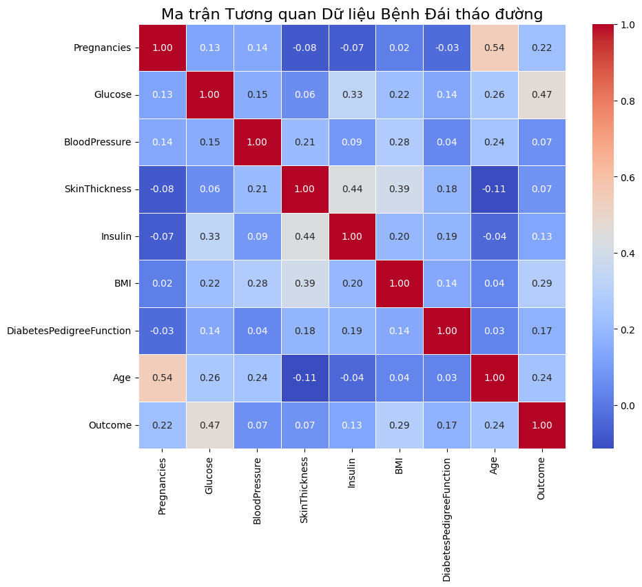

```python
correlation_matrix = df.corr()

plt.figure(figsize=(10, 8))
sns.heatmap(
    correlation_matrix,
    annot=True,              # Hiển thị giá trị
    fmt=".2f",               # Định dạng số
    cmap="coolwarm",         # Bảng màu
    linewidths=.5            # Đường kẻ
)
plt.title('Ma trận Tương quan Dữ liệu Bệnh Đái tháo đường', fontsize=16)
plt.show()
```

```python
correlations = df.corr(method='pearson')
display.display(correlations)
```

|  | Pregnancies | Glucose | BloodPressure | SkinThickness | Insulin | BMI | DiabetesPedigreeFunction | Age | Outcome |
| --- | --- | --- | --- | --- | --- | --- | --- | --- | --- |
| Pregnancies | 1.000000 | 0.129459 | 0.141282 | -0.081672 | -0.073535 | 0.017683 | -0.033523 | 0.544341 | 0.221898 |
| Glucose | 0.129459 | 1.000000 | 0.152590 | 0.057328 | 0.331357 | 0.221071 | 0.137337 | 0.263514 | 0.466581 |
| BloodPressure | 0.141282 | 0.152590 | 1.000000 | 0.207371 | 0.088933 | 0.281805 | 0.041265 | 0.239528 | 0.065068 |
| SkinThickness | -0.081672 | 0.057328 | 0.207371 | 1.000000 | 0.436783 | 0.392573 | 0.183928 | -0.113970 | 0.074752 |
| Insulin | -0.073535 | 0.331357 | 0.088933 | 0.436783 | 1.000000 | 0.197859 | 0.185071 | -0.042163 | 0.130548 |
| BMI | 0.017683 | 0.221071 | 0.281805 | 0.392573 | 0.197859 | 1.000000 | 0.140647 | 0.036242 | 0.292695 |
| DiabetesPedigreeFunction | -0.033523 | 0.137337 | 0.041265 | 0.183928 | 0.185071 | 0.140647 | 1.000000 | 0.033561 | 0.173844 |
| Age | 0.544341 | 0.263514 | 0.239528 | -0.113970 | -0.042163 | 0.036242 | 0.033561 | 1.000000 | 0.238356 |
| Outcome | 0.221898 | 0.466581 | 0.065068 | 0.074752 | 0.130548 | 0.292695 | 0.173844 | 0.238356 | 1.000000 |

## 3.2. Hiển thị dữ liệu

(1) Hiện thị trên từng tính chất đơn

Biểu đồ hộp và râu

https://www.simplypsychology.org/boxplots.html

- So sánh các trung vị (median) tương ứng của mỗi ô hộp (box plot). Nếu đường trung vị của một ô hộp nằm bên ngoài ô của một ô hộp so sánh, thì có thể có sự khác biệt giữa hai nhóm.
- So sánh chiều dài hộp để kiểm tra cách dữ liệu được phân tán giữa mỗi mẫu. Hộp càng dài thì dữ liệu càng phân tán. Dữ liệu càng nhỏ càng ít bị phân tán.
- Một ngoại lệ (outlier) được định nghĩa là một điểm dữ liệu nằm bên ngoài phần rìa (whiskers) của ô hộp.
- Kiểm tra hướng lệch của dữ liệu (cân đối, các phần tử tập trung trái, phải).
  - Median ở giữa hộp và râu (whiskers) ở hai bên như nhau thì phân bố là đối xứng.
  - Median ở gần đáy hộp hơn và nếu râu ngắn hơn ở đầu dưới của hộp, thì phân phối là lệch dương (lệch phải).
  - Median ở gần đầu hộp hơn và nếu râu ngắn hơn ở đầu trên của hộp, thì phân bố bị lệch âm (lệch trái

```python
# Xác định các cột cần xử lý nhiễu
cols_with_outliers = ['SkinThickness', 'Insulin', 'Pregnancies']

# Lặp qua các cột để giới hạn giá trị nhiễu bằng IQR
for col in cols_with_outliers:
    Q1 = df[col].quantile(0.25)
    Q3 = df[col].quantile(0.75)
    IQR = Q3 - Q1

    # Tính giới hạn trên và dưới
    lower_bound = Q1 - 1.5 * IQR
    upper_bound = Q3 + 1.5 * IQR

    # Giới hạn các giá trị nằm ngoài phạm vi
    df[col] = np.where(df[col] < lower_bound, lower_bound, df[col])
    df[col] = np.where(df[col] > upper_bound, upper_bound, df[col])

print("Đã giới hạn Outliers bằng phương pháp IQR.")
```

```
Đã giới hạn Outliers bằng phương pháp IQR.
```

```python
from sklearn.preprocessing import StandardScaler

# Tách X và Y trước khi chuẩn hóa (đã làm ở bước 4.1)
# X = df.drop('Outcome', axis=1)

# Khởi tạo scaler
scaler = StandardScaler()

# Chuẩn hóa tất cả các cột đặc trưng trong X
# Dùng .fit_transform() cho dữ liệu X
X_scaled = scaler.fit_transform(X)

# Chuyển mảng numpy đã được chuẩn hóa trở lại thành DataFrame (để dễ nhìn hơn)
X = pd.DataFrame(X_scaled, columns=X.columns)

print("Đã chuẩn hóa dữ liệu X bằng StandardScaler.")
print("X.head() sau chuẩn hóa:")
print(X.head())
```

```
Đã chuẩn hóa dữ liệu X bằng StandardScaler.
X.head() sau chuẩn hóa:
   Pregnancies   Glucose  BloodPressure  SkinThickness   Insulin       BMI  \
0     0.639947  0.848324       0.149641       0.907270 -0.692891  0.204013
1    -0.844885 -1.123396      -0.160546       0.530902 -0.692891 -0.684422
2     1.233880  1.943724      -0.263941      -1.288212 -0.692891 -1.103255
3    -0.844885 -0.998208      -0.160546       0.154533  0.123302 -0.494043
4    -1.141852  0.504055      -1.504687       0.907270  0.765836  1.409746

   DiabetesPedigreeFunction       Age
0                  0.468492  1.425995
1                 -0.365061 -0.190672
2                  0.604397 -0.105584
3                 -0.920763 -1.041549
4                  5.484909 -0.020496
```

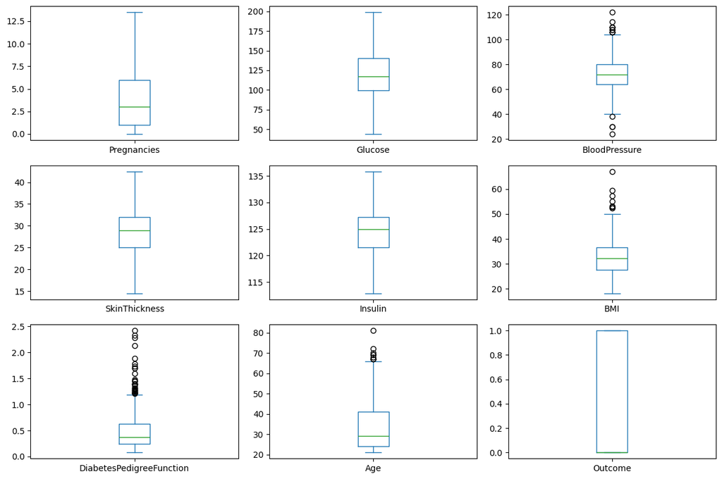

```python
df.plot(kind="box", subplots=True, layout=(3,3), figsize=(12,8), sharex=False, sharey=False)
plt.tight_layout()
plt.show()
```

Biểu đồ Histogram

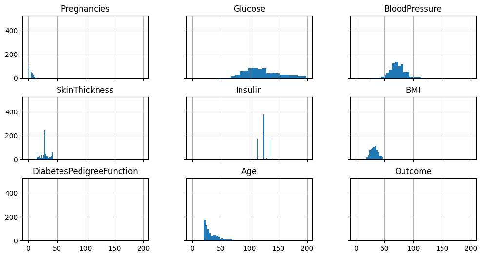

```python
df.hist(figsize=(12, 6), bins = 20, sharex = True, sharey = True);
```

(2) Hiển thị nhiều tính chất (Multivariate Plots)

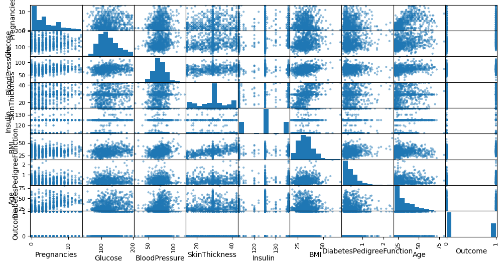

```python
pd.plotting.scatter_matrix(df, figsize=(12,6));
```

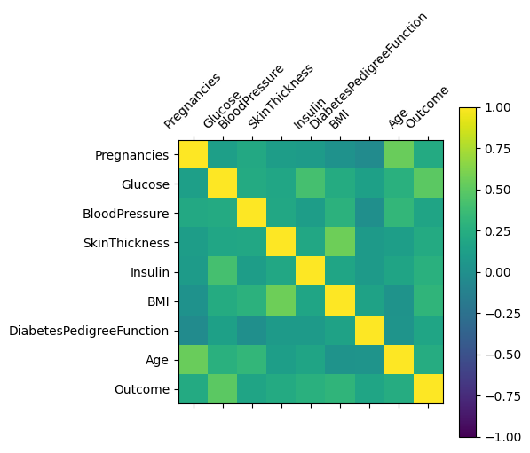

```python
ccorrelations = df.corr()

# Vẽ heatmap
plt.matshow(correlations, vmin=-1, vmax=1)
plt.colorbar()

# Đặt số lượng ticks = số cột
ticks = np.arange(len(df.columns))
plt.xticks(ticks, df.columns, rotation=45)
plt.yticks(ticks, df.columns)

plt.show()
```

## 4. Chuẩn bị dữ liệu(Prepare Data)

### 4.1. Làm Sạch dữ liệu (Data Cleaning)

#### (1) Tạo bảng dữ liệu làm sạch

- Chỉ giữ lại các cột Input, Ouput

```python
df_clean = df.copy()
```

#### (2) Xóa dữ liệu trùng nhau

```python
display.display(df[df.duplicated()])
```

|  | Pregnancies | Glucose | BloodPressure | SkinThickness | Insulin | BMI | DiabetesPedigreeFunction | Age | Outcome |
| --- | --- | --- | --- | --- | --- | --- | --- | --- | --- |

```python
df_clean.drop_duplicates(ignore_index=True, inplace=True)
df_clean
```

|  | Pregnancies | Glucose | BloodPressure | SkinThickness | Insulin | BMI | DiabetesPedigreeFunction | Age | Outcome |
| --- | --- | --- | --- | --- | --- | --- | --- | --- | --- |
| 0 | 6.0 | 148.0 | 72.0 | 35.0 | 125.000 | 33.6 | 0.627 | 50 | 1 |
| 1 | 1.0 | 85.0 | 66.0 | 29.0 | 125.000 | 26.6 | 0.351 | 31 | 0 |
| 2 | 8.0 | 183.0 | 64.0 | 29.0 | 125.000 | 23.3 | 0.672 | 32 | 1 |
| 3 | 1.0 | 89.0 | 66.0 | 23.0 | 112.875 | 28.1 | 0.167 | 21 | 0 |
| 4 | 0.0 | 137.0 | 40.0 | 35.0 | 135.875 | 43.1 | 2.288 | 33 | 1 |
| ... | ... | ... | ... | ... | ... | ... | ... | ... | ... |
| 763 | 10.0 | 101.0 | 76.0 | 42.5 | 135.875 | 32.9 | 0.171 | 63 | 0 |
| 764 | 2.0 | 122.0 | 70.0 | 27.0 | 125.000 | 36.8 | 0.340 | 27 | 0 |
| 765 | 5.0 | 121.0 | 72.0 | 23.0 | 112.875 | 26.2 | 0.245 | 30 | 0 |
| 766 | 1.0 | 126.0 | 60.0 | 29.0 | 125.000 | 30.1 | 0.349 | 47 | 1 |
| 767 | 1.0 | 93.0 | 70.0 | 31.0 | 125.000 | 30.4 | 0.315 | 23 | 0 |

768 rows × 9 columns

#### (3) Xử lý giá trị rỗng, không hợp lệ

```python
has_null = df.isnull().sum().any()
has_nan  = df.isna().sum().any()
print(f'+ Có giá trị Null: {has_null}')
if has_null:
    display.display(df[df.isnull().any(axis=1)])
print(f'+ Có giá trị Nan: {has_nan}')
if has_nan:
    display.display(df[df.isna().any(axis=1)])
```

```
+ Có giá trị Null: False
+ Có giá trị Nan: False
```

### 4.2. Biến đổi dữ liệu ( Data Transforms)

#### (1) Chuyển đổi dữ liệu danh mục thành dữ liệu số

```python
from sklearn.preprocessing import LabelEncoder

# Khởi tạo LabelEncoder
class_encoder = LabelEncoder()

# Fit theo cột Outcome (thay vì "class")
class_encoder.fit(df_clean["Outcome"])

# Lấy danh sách class (0 = không bệnh, 1 = bệnh)
class_names = class_encoder.classes_

print("Các nhãn phân loại:", class_names)
```

```
Các nhãn phân loại: [0 1]
```

```python
class_encoder.transform(df_clean["Outcome"])
```

[output not shown]

[output cut: 20 more lines]

```python
df_clean["Outcome"] = class_encoder.transform(df_clean["Outcome"])
df_clean
```

|  | Pregnancies | Glucose | BloodPressure | SkinThickness | Insulin | BMI | DiabetesPedigreeFunction | Age | Outcome |
| --- | --- | --- | --- | --- | --- | --- | --- | --- | --- |
| 0 | 6.0 | 148.0 | 72.0 | 35.0 | 125.000 | 33.6 | 0.627 | 50 | 1 |
| 1 | 1.0 | 85.0 | 66.0 | 29.0 | 125.000 | 26.6 | 0.351 | 31 | 0 |
| 2 | 8.0 | 183.0 | 64.0 | 29.0 | 125.000 | 23.3 | 0.672 | 32 | 1 |
| 3 | 1.0 | 89.0 | 66.0 | 23.0 | 112.875 | 28.1 | 0.167 | 21 | 0 |
| 4 | 0.0 | 137.0 | 40.0 | 35.0 | 135.875 | 43.1 | 2.288 | 33 | 1 |
| ... | ... | ... | ... | ... | ... | ... | ... | ... | ... |
| 763 | 10.0 | 101.0 | 76.0 | 42.5 | 135.875 | 32.9 | 0.171 | 63 | 0 |
| 764 | 2.0 | 122.0 | 70.0 | 27.0 | 125.000 | 36.8 | 0.340 | 27 | 0 |
| 765 | 5.0 | 121.0 | 72.0 | 23.0 | 112.875 | 26.2 | 0.245 | 30 | 0 |
| 766 | 1.0 | 126.0 | 60.0 | 29.0 | 125.000 | 30.1 | 0.349 | 47 | 1 |
| 767 | 1.0 | 93.0 | 70.0 | 31.0 | 125.000 | 30.4 | 0.315 | 23 | 0 |

768 rows × 9 columns

#### (2) Chuyển đổi dữ liệu danh mục thành OneHot

Một số thuật toán khi chuyển đổi cột dạng danh mục thành kiểu OneHot thì cho hiệu suất cao hơn.

Bên cạnh đó, khi huấn luyện mô hình với dạng hàm mất mát CategoryEntropy thì cũng cần chuyển thuộc tính phân lớp sang dạng OneHot.

```python
df_outcome_onehot = pd.get_dummies(df_clean["Outcome"], prefix="Outcome")

print(df_outcome_onehot.head())
```

```
   Outcome_0  Outcome_1
0      False       True
1       True      False
2      False       True
3       True      False
4      False       True
```

```python
# One-hot encoding cho Outcome
df_outcome_onehot = pd.get_dummies(df_clean["Outcome"])

# Đổi tên cột cho dễ hiểu
df_outcome_onehot = pd.DataFrame(df_outcome_onehot.values,
                                 columns=["No_Diabetes", "Diabetes"])
df_outcome_onehot.head()
```

|  | No_Diabetes | Diabetes |
| --- | --- | --- |
| 0 | False | True |
| 1 | True | False |
| 2 | False | True |
| 3 | True | False |
| 4 | False | True |

#### (3) Chuẩn hóa dữ liệu (Data Normalize)

Chuẩn hóa các tính chất để đưa về cùng một miền trị

- Min-Max Normalization $$ z = \frac{x - min(x)}{max(x) - min(x)} $$
- Standard Normalization $$ z = \frac{x - \mu}{\sigma} $$

**Lưu ý**: Quá trình chuẩn hóa có thể làm trong phần thực nghiệm thuật toán

```python
from sklearn.preprocessing import MinMaxScaler

# Các cột cần scale (bỏ Outcome vì đó là nhãn phân loại)
scale_columns = ["Pregnancies", "Glucose", "BloodPressure", "SkinThickness",
                 "Insulin", "BMI", "DiabetesPedigreeFunction", "Age"]

# Khởi tạo scaler
minmax_scaler = MinMaxScaler()

# Fit và transform
df_clean_minmax = df_clean.copy()
df_clean_minmax[scale_columns] = minmax_scaler.fit_transform(df_clean[scale_columns])

df_clean_minmax.head()
```

|  | Pregnancies | Glucose | BloodPressure | SkinThickness | Insulin | BMI | DiabetesPedigreeFunction | Age | Outcome |
| --- | --- | --- | --- | --- | --- | --- | --- | --- | --- |
| 0 | 0.444444 | 0.670968 | 0.489796 | 0.732143 | 0.527174 | 0.314928 | 0.234415 | 0.483333 | 1 |
| 1 | 0.074074 | 0.264516 | 0.428571 | 0.517857 | 0.527174 | 0.171779 | 0.116567 | 0.166667 | 0 |
| 2 | 0.592593 | 0.896774 | 0.408163 | 0.517857 | 0.527174 | 0.104294 | 0.253629 | 0.183333 | 1 |
| 3 | 0.074074 | 0.290323 | 0.428571 | 0.303571 | 0.000000 | 0.202454 | 0.038002 | 0.000000 | 0 |
| 4 | 0.000000 | 0.600000 | 0.163265 | 0.732143 | 1.000000 | 0.509202 | 0.943638 | 0.200000 | 1 |

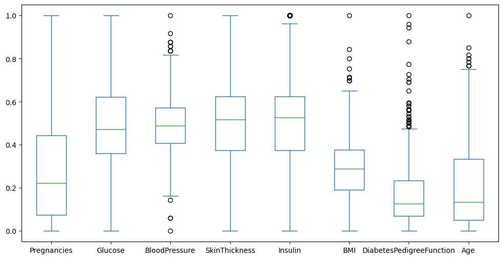

```python
df_clean_minmax[scale_columns].plot(kind="box", figsize=(12,6));
```

```python
standard_scaler = StandardScaler()
standard_scaler.fit(df_clean[scale_columns])
df_clean_standard = df_clean.copy()
df_clean_standard[scale_columns] = standard_scaler.transform(df_clean[scale_columns])
df_clean_standard
```

|  | Pregnancies | Glucose | BloodPressure | SkinThickness | Insulin | BMI | DiabetesPedigreeFunction | Age | Outcome |
| --- | --- | --- | --- | --- | --- | --- | --- | --- | --- |
| 0 | 0.647150 | 0.866045 | -0.031990 | 0.824667 | 0.039062 | 0.166619 | 0.468492 | 1.425995 | 1 |
| 1 | -0.848970 | -1.205066 | -0.528319 | 0.017945 | 0.039062 | -0.852200 | -0.365061 | -0.190672 | 0 |
| 2 | 1.245598 | 2.016662 | -0.693761 | 0.017945 | 0.039062 | -1.332500 | 0.604397 | -0.105584 | 1 |
| 3 | -0.848970 | -1.073567 | -0.528319 | -0.788777 | -1.494110 | -0.633881 | -0.920763 | -1.041549 | 0 |
| 4 | -1.148194 | 0.504422 | -2.679076 | 0.824667 | 1.414175 | 1.549303 | 5.484909 | -0.020496 | 1 |
| ... | ... | ... | ... | ... | ... | ... | ... | ... | ... |
| 763 | 1.844045 | -0.679069 | 0.298896 | 1.833069 | 1.414175 | 0.064737 | -0.908682 | 2.532136 | 0 |
| 764 | -0.549746 | 0.011301 | -0.197433 | -0.250963 | 0.039062 | 0.632365 | -0.398282 | -0.531023 | 0 |
| 765 | 0.347926 | -0.021574 | -0.031990 | -0.788777 | -1.494110 | -0.910418 | -0.685193 | -0.275760 | 0 |
| 766 | -0.848970 | 0.142800 | -1.024647 | 0.017945 | 0.039062 | -0.342790 | -0.371101 | 1.170732 | 1 |
| 767 | -0.848970 | -0.942068 | -0.197433 | 0.286852 | 0.039062 | -0.299127 | -0.473785 | -0.871374 | 0 |

768 rows × 9 columns

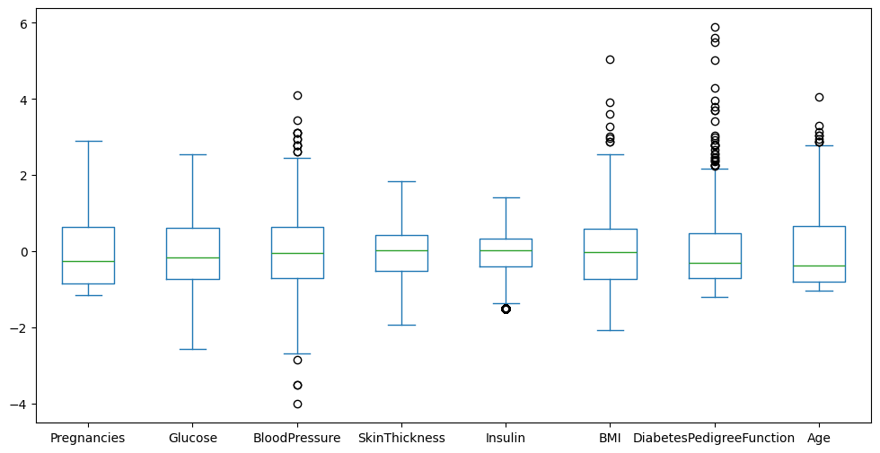

```python
df_clean_standard[scale_columns].plot(kind="box", figsize=(12,6));
```

```python
correlations = df_clean_standard.corr(method='pearson')
display.display(correlations)
```

|  | Pregnancies | Glucose | BloodPressure | SkinThickness | Insulin | BMI | DiabetesPedigreeFunction | Age | Outcome |
| --- | --- | --- | --- | --- | --- | --- | --- | --- | --- |
| Pregnancies | 1.000000 | 0.126856 | 0.210437 | 0.110471 | 0.097060 | 0.019501 | -0.034448 | 0.546107 | 0.220392 |
| Glucose | 0.126856 | 1.000000 | 0.218937 | 0.181371 | 0.413981 | 0.231049 | 0.137327 | 0.266909 | 0.492782 |
| BloodPressure | 0.210437 | 0.218937 | 1.000000 | 0.198478 | 0.110930 | 0.281257 | -0.002378 | 0.324915 | 0.165723 |
| SkinThickness | 0.110471 | 0.181371 | 0.198478 | 1.000000 | 0.200742 | 0.555910 | 0.086177 | 0.124119 | 0.220111 |
| Insulin | 0.097060 | 0.413981 | 0.110930 | 0.200742 | 1.000000 | 0.179240 | 0.086157 | 0.166583 | 0.266382 |
| BMI | 0.019501 | 0.231049 | 0.281257 | 0.555910 | 0.179240 | 1.000000 | 0.153438 | 0.025597 | 0.312038 |
| DiabetesPedigreeFunction | -0.034448 | 0.137327 | -0.002378 | 0.086177 | 0.086157 | 0.153438 | 1.000000 | 0.033561 | 0.173844 |
| Age | 0.546107 | 0.266909 | 0.324915 | 0.124119 | 0.166583 | 0.025597 | 0.033561 | 1.000000 | 0.238356 |
| Outcome | 0.220392 | 0.492782 | 0.165723 | 0.220111 | 0.266382 | 0.312038 | 0.173844 | 0.238356 | 1.000000 |

#### (4) Chia dữ liệu thực nghiệm

- Chuyển đổi dữ liệu sang dạng numpy với phần Input (X_data), Output (y_data)
- Chia dữ liệu thành tập train/test (tỷ lệ 70/30)
- Lưu tất cả thông tin để chuẩn bị chạy thuật toán

```python
X_data, y_data = df_clean.values[:, :-1], df_clean.values[:, -1]
X_data.shape, y_data.shape
print(X_data[:20, :])
print(y_data[:20])
```

```
[[6.00000e+00 1.48000e+02 7.20000e+01 3.50000e+01 1.25000e+02 3.36000e+01
  6.27000e-01 5.00000e+01]
 [1.00000e+00 8.50000e+01 6.60000e+01 2.90000e+01 1.25000e+02 2.66000e+01
  3.51000e-01 3.10000e+01]
 [8.00000e+00 1.83000e+02 6.40000e+01 2.90000e+01 1.25000e+02 2.33000e+01
  6.72000e-01 3.20000e+01]
 [1.00000e+00 8.90000e+01 6.60000e+01 2.30000e+01 1.12875e+02 2.81000e+01
  1.67000e-01 2.10000e+01]
 [0.00000e+00 1.37000e+02 4.00000e+01 3.50000e+01 1.35875e+02 4.31000e+01
  2.28800e+00 3.30000e+01]
 [5.00000e+00 1.16000e+02 7.40000e+01 2.90000e+01 1.25000e+02 2.56000e+01
  2.01000e-01 3.00000e+01]
 [3.00000e+00 7.80000e+01 5.00000e+01 3.20000e+01 1.12875e+02 3.10000e+01
  2.48000e-01 2.60000e+01]
 [1.00000e+01 1.15000e+02 7.20000e+01 2.90000e+01 1.25000e+02 3.53000e+01
  1.34000e-01 2.90000e+01]
 [2.00000e+00 1.97000e+02 7.00000e+01 4.25000e+01 1.35875e+02 3.05000e+01
  1.58000e-01 5.30000e+01]
 [8.00000e+00 1.25000e+02 9.60000e+01 2.90000e+01 1.25000e+02 3.23000e+01
  2.32000e-01 5.40000e+01]
 [4.00000e+00 1.10000e+02 9.20000e+01 2.90000e+01 1.25000e+02 3.76000e+01
  1.91000e-01 3.00000e+01]
 [1.00000e+01 1.68000e+02 7.40000e+01 2.90000e+01 1.25000e+02 3.80000e+01
  5.37000e-01 3.40000e+01]
 [1.00000e+01 1.39000e+02 8.00000e+01 2.90000e+01 1.25000e+02 2.71000e+01
  1.44100e+00 5.70000e+01]
 [1.00000e+00 1.89000e+02 6.00000e+01 2.30000e+01 1.35875e+02 3.01000e+01
  3.98000e-01 5.90000e+01]
 [5.00000e+00 1.66000e+02 7.20000e+01 1.90000e+01 1.35875e+02 2.58000e+01
  5.87000e-01 5.10000e+01]
 [7.00000e+00 1.00000e+02 7.20000e+01 2.90000e+01 1.25000e+02 3.00000e+01
  4.84000e-01 3.20000e+01]
 [0.00000e+00 1.18000e+02 8.40000e+01 4.25000e+01 1.35875e+02 4.58000e+01
  5.51000e-01 3.10000e+01]
 [7.00000e+00 1.07000e+02 7.40000e+01 2.90000e+01 1.25000e+02 2.96000e+01
  2.54000e-01 3.10000e+01]
 [1.00000e+00 1.03000e+02 3.00000e+01 3.80000e+01 1.12875e+02 4.33000e+01
  1.83000e-01 3.30000e+01]
 [1.00000e+00 1.15000e+02 7.00000e+01 3.00000e+01 1.12875e+02 3.46000e+01
  5.29000e-01 3.20000e+01]]
[1. 0. 1. 0. 1. 0. 1. 0. 1. 1. 0. 1. 0. 1. 1. 1. 1. 1. 0. 1.]
```

```python
X_train, X_test, y_train, y_test = train_test_split(X_data, y_data, train_size=0.7)
print(f'+ Train/Test: Train Ratio = {len(X_train)/len(X_data)}')
print(f'+ Train: shape={X_train.shape}\nInput = \n{X_train[:5]}\nOutput = {y_train[:5]}')
print(f'+ Test: shape={X_test.shape}\nInput = \n{X_test[:5]}\nOutput = {y_test[:5]}')
```

```
+ Train/Test: Train Ratio = 0.69921875
+ Train: shape=(537, 8)
Input =
[[2.00000e+00 9.20000e+01 6.20000e+01 2.80000e+01 1.25000e+02 3.16000e+01
  1.30000e-01 2.40000e+01]
 [0.00000e+00 1.23000e+02 8.80000e+01 3.70000e+01 1.25000e+02 3.52000e+01
  1.97000e-01 2.90000e+01]
 [2.00000e+00 8.70000e+01 7.20000e+01 2.30000e+01 1.25000e+02 2.89000e+01
  7.73000e-01 2.50000e+01]
 [0.00000e+00 1.08000e+02 6.80000e+01 2.00000e+01 1.25000e+02 2.73000e+01
  7.87000e-01 3.20000e+01]
 [6.00000e+00 1.29000e+02 9.00000e+01 1.45000e+01 1.35875e+02 1.96000e+01
  5.82000e-01 6.00000e+01]]
Output = [0. 0. 0. 0. 0.]
+ Test: shape=(231, 8)
Input =
[[  1.    139.     62.     41.    135.875  40.7     0.536  21.   ]
 [  3.    113.     50.     14.5   112.875  29.5     0.626  25.   ]
 [  9.     89.     62.     29.    125.     22.5     0.142  33.   ]
 [  8.    120.     78.     29.    125.     25.      0.409  64.   ]
 [  1.     97.     70.     40.    125.     38.1     0.218  30.   ]]
Output = [0. 0. 0. 0. 0.]
```

```python
# Lưu thông tin
save_dir = "exps/iris"
if os.path.exists(save_dir) == False: os.makedirs(save_dir)

# Save training data
np.savez(f'{save_dir}/data.npz', X_train=X_train, X_test=X_test, y_train=y_train, y_test=y_test)
# Save cleaning data
df_clean.to_excel(f'{save_dir}/df_clean.xlsx', index=False)
# Save encoders
joblib.dump(class_encoder, f'{save_dir}/class_encoder.joblib')

os.listdir(save_dir)
```

```
['class_encoder.joblib', 'data.npz', 'df_clean.xlsx']
```

```python
# Kiểm tra phục hồi dữ liệu
dict(np.load(f'{save_dir}/data.npz')).keys()
```

```
dict_keys(['X_train', 'X_test', 'y_train', 'y_test'])
```

```python
pd.read_excel(f'{save_dir}/df_clean.xlsx')
```

|  | Pregnancies | Glucose | BloodPressure | SkinThickness | Insulin | BMI | DiabetesPedigreeFunction | Age | Outcome |
| --- | --- | --- | --- | --- | --- | --- | --- | --- | --- |
| 0 | 6.0 | 148 | 72 | 35.0 | 125.000 | 33.6 | 0.627 | 50 | 1 |
| 1 | 1.0 | 85 | 66 | 29.0 | 125.000 | 26.6 | 0.351 | 31 | 0 |
| 2 | 8.0 | 183 | 64 | 29.0 | 125.000 | 23.3 | 0.672 | 32 | 1 |
| 3 | 1.0 | 89 | 66 | 23.0 | 112.875 | 28.1 | 0.167 | 21 | 0 |
| 4 | 0.0 | 137 | 40 | 35.0 | 135.875 | 43.1 | 2.288 | 33 | 1 |
| ... | ... | ... | ... | ... | ... | ... | ... | ... | ... |
| 763 | 10.0 | 101 | 76 | 42.5 | 135.875 | 32.9 | 0.171 | 63 | 0 |
| 764 | 2.0 | 122 | 70 | 27.0 | 125.000 | 36.8 | 0.340 | 27 | 0 |
| 765 | 5.0 | 121 | 72 | 23.0 | 112.875 | 26.2 | 0.245 | 30 | 0 |
| 766 | 1.0 | 126 | 60 | 29.0 | 125.000 | 30.1 | 0.349 | 47 | 1 |
| 767 | 1.0 | 93 | 70 | 31.0 | 125.000 | 30.4 | 0.315 | 23 | 0 |

768 rows × 9 columns

```python
joblib.load(f'{save_dir}/class_encoder.joblib').classes_
```

```
array([0, 1])
```